# Should We Stop the Experiment?: Decision-making and Bayesian Hurdle Models

Christopher Gandrud

2018-05-13

> Note: the full source for this paper is available at: https://github.com/christophergandrud/bayes_hurdle_decision.

# Problem

Imagine that you plan to run an experiment of a new feature on an e-commerce site. You think the new feature will have a positive effect on your revenue, but don’t know for sure (otherwise you wouldn’t need to do the experiment).

You set up your experment using standard procedures for determining its runtime. However, in the case that during the course of the experiment, it looks like you are losing money because the treatment seems to be perfoming worse than the control:

E.g. using a sample size that gives you a power level of 80% and significance level of 5% for your anticipated treatment effect size.

- how much money would be too much to lose and
- how would you know when you have lost that amount of money?

At first glance this seems like an straightforward problem. First, your boss owns the company’s utility function. Ask them how much money they are willing to lose to find out the new feature’s performance. Second, start the experiment and monitor the difference in revenue between the control and treatment groups. If this difference (for the same number of observations) becomes equal to or bigger than the number your boss gave you, stop the experiment.

Seems easy enough.

However, how do you know you actually lost that amount of money due to the new feature introduced as a treatment? How do you know that it wasn’t also generated by chance because of **sampling error**? For example, imagine we have control and treatment groups with the following distributions for 10,000 observations each. Note, I simulated these using the same distribution, i.e. there is actually no difference between the control and treatment groups.

Each simulated value $n$ is drawn from the following bernoulli-log normal hurdle probability function: $y \sim \begin{cases} 0 & \mathrm{with\: probability}\: 0.4 \\ \ln(\mathcal{N}(20, 2.7)) & \mathrm{if}\: y > 0 \end{cases}$

Observed distribution of results from an a/b test that is actually an a/a test

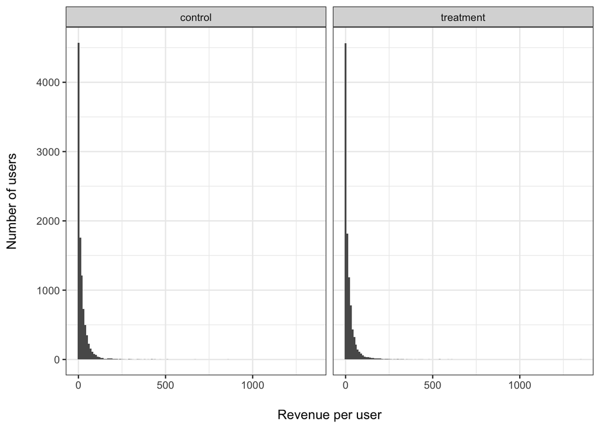

The difference in revenue between the control and treatment variants is -4011. This difference exists despite the two groups being from exactly the same distribution. There is no difference between the treatment effect and the control effect! In other words, this difference is not caused by the experiment. The experiment cost/gained us no revenue

# Solution

One solution to this problem is to take sampling error into consideration by directly **estimating how uncertain** we are about how much the experiment is costing us and compare this to how certain we want to be that the experiment is costing us a certain amount.

These are the three broad steps:

1. Specify the **range of costs** you would consider to be unacceptable to find out the effect of the treatment.
2. Us the data from your experiment to simulate our **best guess of the range of costs** that the experiment has incurred.
3. **If** these two ranges overlap, stop the test, if not keep going.

## Finding our best guess

The second step is methodologically the most tricky. Our most naive guess of the costs of our experiment is simply the difference in the total revenue between the control and treatment groups. However, as we already saw, this does not include sampling error.

We can use Bayesian methods to estimate the true cost of the experiment. To do this we need to first understand the data we observe in the experiment and use it to estimate the range of likely costs caused by the experiment. To do this let’s first think of the process that created the data, the **data generating process**:

For a discussion of why traditional confidence intervals are problematic for this problem see: http://doingbayesiandataanalysis.blogspot.de/2013/11/optional-stopping-in-data-collection-p.html

1. A customer comes to the website and is exposed to the control or treatment. In both cases, they have the option to purchase something.
2. They decide whether or not to purchase something.
3. If they decide to purchase, they decide how much to purchase.

This data generating process suggests that the revenue data we observe from our experiments are from a **hurdle model**. Data from a hurdle model are created by two parts. The first is a Bernoulli probability of whether or not a customer makes a purchase. The second part is some other distribution describing how much they purchase. If “how much they purchase” means number of items, then a useful distribution would be the poisson distribution for count data. In our case, we care about the Euro value of their purchase, so something like the log-normal or gamma distribution is appropriate.

For a clear explanation of hurdle models see: https://stats.stackexchange.com/a/81854

The log-normal distribution is relatively easy to understand. It is simply logarithm of the normal distribution and expresses highly right skewed data, which sales per customer tend to be.

# A/A test example

Let’s use this decision-making process with the data we saw above: where the control and treatment have the same effect on revenue.

I am using Markov Chain Monte Carlo (MCMC) via the Stan probablistic programming language (http://mc-stan.org/).

`b_intercept` is the log-normal mean for the control group which we had set at 3, i.e. $\exp(3) \approx 20$. `varianttreatment` is how much the treatment group’s mean is different from the control group in this case they are the same, so the true value is 0. `sigma` is the standard deviation of the log-normal part, which we set to 1. `hu` is the probability of not clearing the hurdle, which we had set at 0.4.

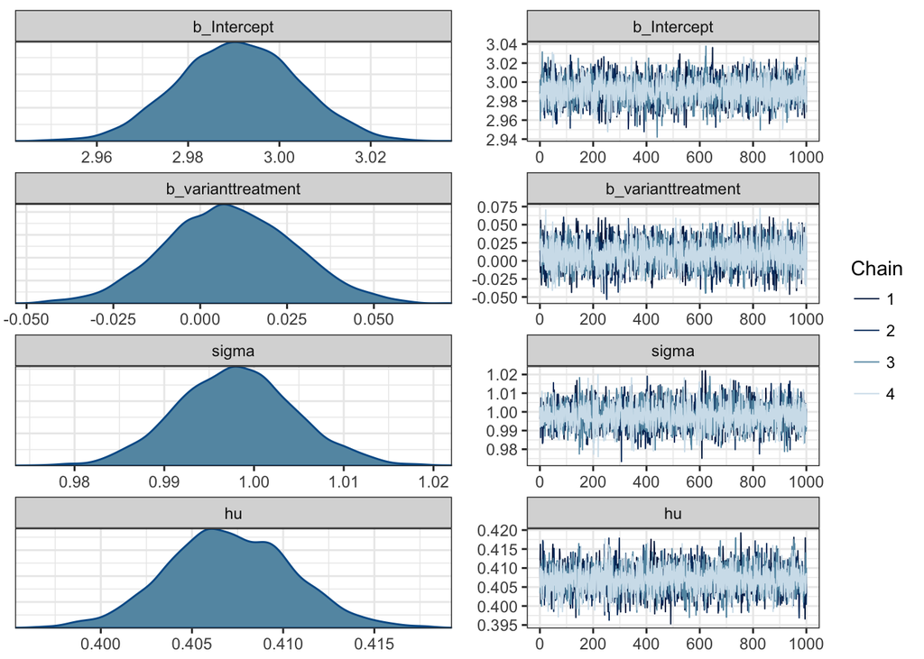

Posterior parameters from a/b test that is actually an a/a test

Now that we have many draws from the parameters’ posterior distributions, we can come up with the same number of simulations of our quantity of interest: how different the revenue is between the control and treatment groups. We can do this with the following steps:

1. For each draw from the posterior find simulate the expected revenue for the control and treatment at approximately the on-going experiment’s current sample size (with equal numbers for the two groups).
2. For each simulation, sum up the revenue for each group and find the difference.
3. Plot the 95% highest posterior density interval (HDI) of the distribution of simulations.

   http://doingbayesiandataanalysis.blogspot.de/2012/04/why-to-use-highest-density-intervals.html
4. See if it overlaps with our stopping criteria interval. If it does, stop the test.

See the source code for details of how this is done.

https://github.com/christophergandrud/bayes_hurdle_decision

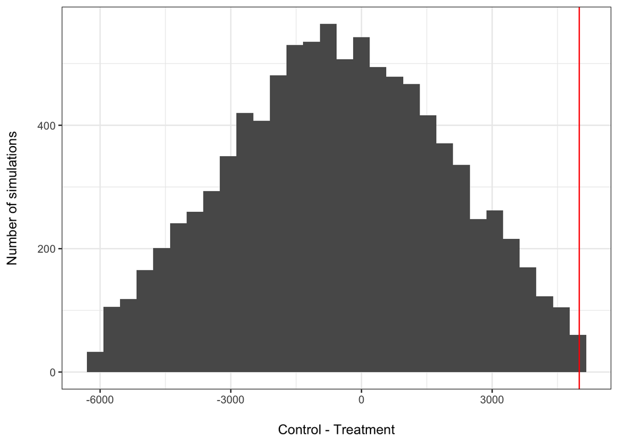

There is very little overlap. We can be confident that we have not exceeded our experiment cutoff limit and continue the experiment.

# A/B Test Example

Finally, let’s see what this would look like if the treatment actually does produce lower revenue than the control. In this case, we simulate a control group of “observed data” from the distribution described at the beginning of this piece. The treatment group is from a a slightly different distribution: the log-mean of the log-normal part is set to 2.8 ($\exp(2.8) \approx 16.4$). Once we have this “observed” data, we then follow the decision-making steps and end up with the following posterior distribution of costs of running the experiment for 10,000 customers in each group:

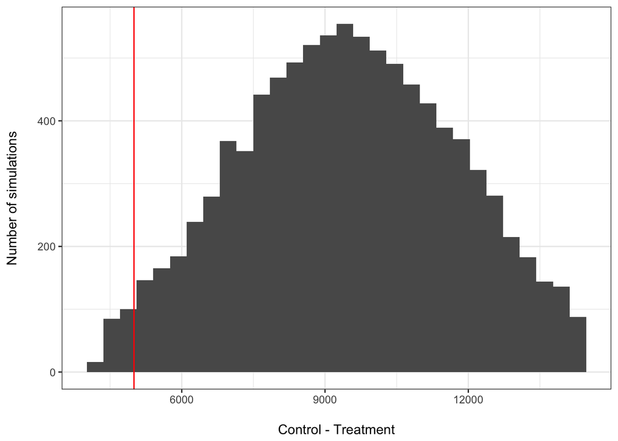

Almost the entire HDI is above the accepted cost cut-off, so we would decide to stop the experiment.